# Examen Lab

Carlos Santiago Martinez Torres

2025-05-26

# 1 Creacion de proyecto

## 1.1 Configuracion inicial

Limpiamos el entorno para no tener conflicto con ficheros o archivos anteriores.

Instalamos las librerias necesarias para este proyecto.

## 1.2 Carpetas de interes

Creamos las carpetas para almacenar los ficheros a tratar y figuras, en caso de ser necesarias.

# 2 Importacion

Importamos el fichero que esta almacenado en la carpeta data.

```r
f <- paste0(datos, 'logs_2024_25_TD.csv')

# Codificacion mas probable
guess_encoding(file = f) # UTF-8
```

```
## # A tibble: 3 × 2
##   encoding   confidence
##   <chr>           <dbl>
## 1 UTF-8            1
## 2 ISO-8859-1       0.55
## 3 ISO-8859-2       0.29
```

```r
# Importacion
df <- read.csv(file = f, header = TRUE)

# Renombrar
colnames(df) <- c('Hora', 'Contexto', 'Componente', 'NomEv', 'Descripcion', 'Origen', 'IP', 'User')
colnames(df)
```

```
## [1] "Hora"        "Contexto"    "Componente"  "NomEv"       "Descripcion"
## [6] "Origen"      "IP"          "User"
```

```r
# Cambio de formato de Hora
df <- df %>%
  mutate(Hora = dmy_hms(Hora))

head(df, 5)
```

```
##                  Hora                                              Contexto
## 1 2025-05-06 22:50:31 Curso: 2024-25 Tractament de les dades Gr.A-T (36423)
## 2 2025-05-06 22:50:29 Curso: 2024-25 Tractament de les dades Gr.A-T (36423)
## 3 2025-05-06 22:44:12 Curso: 2024-25 Tractament de les dades Gr.A-T (36423)
## 4 2025-05-06 22:43:49          Archivo: Examen escrito 2022 1ª convocatoria
## 5 2025-05-06 22:41:52                     Cuestionario: Cuestionario Tema 5
##     Componente                   NomEv
## 1      Sistema Lista de usuarios vista
## 2      Sistema Lista de usuarios vista
## 3      Sistema             Curso visto
## 4      Recurso   Módulo de curso visto
## 5 Cuestionario   Módulo de curso visto
##                                                                                                              Descripcion
## 1                   The user with id &#039;22872&#039; viewed the list of users in the course with id &#039;85837&#039;.
## 2                   The user with id &#039;22872&#039; viewed the list of users in the course with id &#039;85837&#039;.
## 3                                        The user with id &#039;22872&#039; viewed the course with id &#039;85837&#039;.
## 4 The user with id &#039;22872&#039; viewed the &#039;resource&#039; activity with course module id &#039;2417152&#039;.
## 5    The user with id &#039;305739&#039; viewed the &#039;quiz&#039; activity with course module id &#039;2947035&#039;.
##   Origen           IP     User
## 1    web 62.43.76.160 143ff85a
## 2    web 62.43.76.160 143ff85a
## 3    web 62.43.76.160 143ff85a
## 4    web 62.43.76.160 143ff85a
## 5    web 90.69.79.109 612cb0a9
```

```r
# Comprobamos
str(df)
```

```
## 'data.frame':    66710 obs. of  8 variables:
##  $ Hora       : POSIXct, format: "2025-05-06 22:50:31" "2025-05-06 22:50:29" ...
##  $ Contexto   : chr  "Curso: 2024-25 Tractament de les dades Gr.A-T (36423)" "Curso: 2024-25 Tractament de les dades Gr.A-T (36423)" "Curso: 2024-25 Tractament de les dades Gr.A-T (36423)" "Archivo: Examen escrito 2022 1ª convocatoria" ...
##  $ Componente : chr  "Sistema" "Sistema" "Sistema" "Recurso" ...
##  $ NomEv      : chr  "Lista de usuarios vista" "Lista de usuarios vista" "Curso visto" "Módulo de curso visto" ...
##  $ Descripcion: chr  "The user with id &#039;22872&#039; viewed the list of users in the course with id &#039;85837&#039;." "The user with id &#039;22872&#039; viewed the list of users in the course with id &#039;85837&#039;." "The user with id &#039;22872&#039; viewed the course with id &#039;85…
##  $ Origen     : chr  "web" "web" "web" "web" ...
##  $ IP         : chr  "62.43.76.160" "62.43.76.160" "62.43.76.160" "62.43.76.160" ...
##  $ User       : chr  "143ff85a" "143ff85a" "143ff85a" "143ff85a" ...
```

# 3 Consultas eventos

Listado de usuarios distintos registrados.

```r
# Usuarios distintos
# df %>%
#   distinct(User)
```

Total de usuarios distintos.

```r
# Total usuarios distintos
df %>%
  distinct(User) %>%
  count()
```

```
##    n
## 1 84
```

Usuarios con mas y menos logs.

```r
# 5 usuarios con mas logs
df %>%
  group_by(User) %>%
  count() %>%
  arrange(desc(n)) %>%
  head(5)
```

```
## # A tibble: 5 × 2
## # Groups:   User [5]
##   User         n
##   <chr>    <int>
## 1 143ff85a  8258
## 2 bd80f01c  1606
## 3 6cd957b7  1484
## 4 7c8e8f5c  1296
## 5 d5007f33  1277
```

```r
# 5 usuarios con menos logs
df %>%
  group_by(User) %>%
  count() %>%
  arrange(n) %>%
  head(5)
```

```
## # A tibble: 5 × 2
## # Groups:   User [5]
##   User         n
##   <chr>    <int>
## 1 8b6b27a2     1
## 2 c90f5c72     1
## 3 b237792a     2
## 4 b45bab56     3
## 5 f6d97665     3
```

# 4 Mas conexiones

Actualizamos el df creando las variables con la hora redondeada y con la hora especifica del dia.

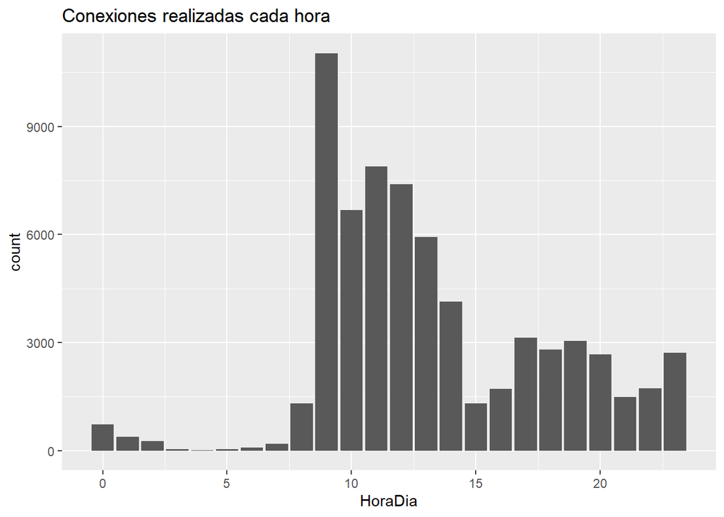

```r
# Horas y dias
df <- df %>%
  mutate(HoraR = floor_date(Hora, unit = 'hour'),
         HoraDia = hour(HoraR))

df %>%
  ggplot(data = ., mapping = aes(x = HoraDia)) +
  geom_bar() +
  labs(title = 'Conexiones realizadas cada hora')
```

Teniendo en cuenta el apartado anterior, tomamos los registros que tengan una hora entre 2 y 4.

```r
# Eventos entre 2 y 4
df %>%
  filter(HoraDia > 2 & HoraDia < 4) %>%
  count()
```

```
##    n
## 1 36
```

# 5 Mejor dia para parar AV

```r
df %>%
  select(Hora) %>%
  mutate(dia = format(x = as.Date(Hora), format = '%A')) %>%
  count(dia) %>%
  arrange(n)
```

```
##         dia     n
## 1    sábado  1762
## 2   domingo  2640
## 3     lunes  9383
## 4    jueves  9941
## 5   viernes 12036
## 6    martes 14079
## 7 miércoles 16869
```

El mejor dia para parar el AV es el sabado, que es cuando menos conexiones hay.

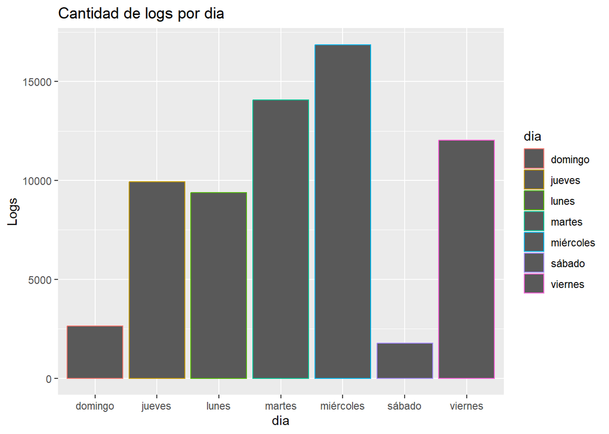

```r
# dias_semana <- c('lunes', 'martes', 'miercoles', 'jueves', 'viernes')
df %>%
  select(Hora) %>%
  mutate(dia = format(x = as.Date(Hora), format = '%A')) %>%
  # count(dia) %>%
  ggplot(data = ., mapping = aes(x = dia)) +
  geom_bar(aes(color = dia)) +
  labs(title = 'Cantidad de logs por dia',
       y = 'Logs',
       x = 'dia')
```

# 6 Contexto DataCamp

Identificamos la cantidad de cursos distintos que hay de DataCamp para contar cuantos hay por cada uno y graficar para ver si estan solapados o no en cuanto a las fechas.

```r
# datacamp <- df[str_detect(string = df$NomEv, pattern = 'Entrega creada'), ]

# Cursos distintos
df %>%
  filter(grepl('DataCamp', Contexto, ignore.case = TRUE) & grepl('Entrega creada', NomEv, ignore.case = TRUE)) %>%
  distinct(Contexto)
```

```
##                                                     Contexto
## 1                  Tarea: Tarea Cleaning Data in R(Datacamp)
## 2   Tarea: Tarea Understanding Data Visualization (Datacamp)
## 3 Tarea: Tarea Introduction to Importing Data in R(Datacamp)
## 4                      Tarea: Tarea Intermediate R(Datacamp)
## 5                   Tarea: Tarea Introduction to R(Datacamp)
```

```r
# Alumnos por curso
df %>%
  filter(grepl('DataCamp', Contexto, ignore.case = TRUE) & grepl('Entrega creada', NomEv, ignore.case = TRUE)) %>%
  count(Contexto)
```

```
##                                                     Contexto  n
## 1                  Tarea: Tarea Cleaning Data in R(Datacamp) 39
## 2                      Tarea: Tarea Intermediate R(Datacamp) 62
## 3 Tarea: Tarea Introduction to Importing Data in R(Datacamp) 58
## 4                   Tarea: Tarea Introduction to R(Datacamp) 54
## 5   Tarea: Tarea Understanding Data Visualization (Datacamp) 53
```

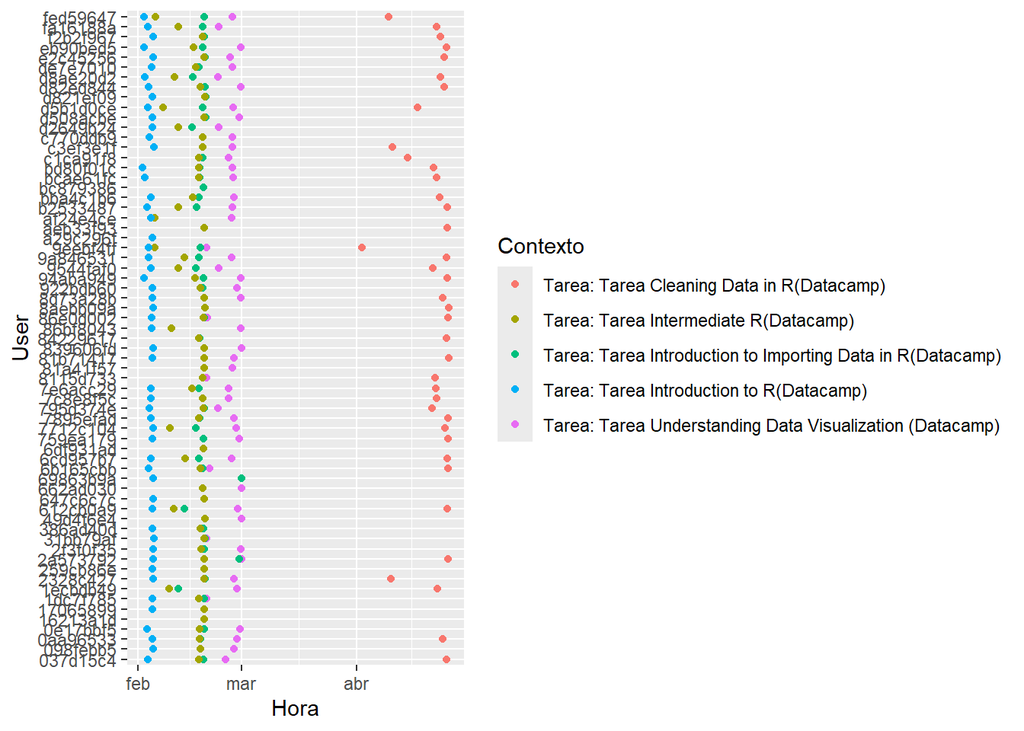

```r
# Cursos solapados
df %>%
  filter(grepl('DataCamp', Contexto, ignore.case = TRUE) & grepl('Entrega creada', NomEv, ignore.case = TRUE)) %>%
  ggplot(data = ., mapping = aes(x = Hora, y = User, color = Contexto)) +
  geom_point()
```

# 7 Direccion IP

Identifamos las IP con el formato correcto

```r
formatoIP = '([0-9])+{3}\\.([0-9])+{3}\\.([0-9])+{3}\\.([0-9])+{3}'
```

Obtencion del df que contiene el Id correcto

```r
df_IP <- df %>%
  filter(grepl(formatoIP, IP, ignore.case = TRUE))
```

Comprobar el numero de conexiones por usuario

```r
# Numero de conexiones - Diferentes IPs
df_IP %>%
  distinct(IP) %>%
  count()
```

```
##    n
## 1 61
```

```r
# Numero de usuarios diferentes con el formato de IP correcto
df_IP %>%
  distinct(User) %>%
  count()
```

```
##    n
## 1 22
```

```r
# Usuarios con mas de 2 IPs
df_IP %>%
  count(User) %>%
  filter(n > 2) %>%
  arrange(n)
```

```
##        User   n
## 1  81a41f57   3
## 2  94aba949   4
## 3  037d15c4   6
## 4  839606fd   6
## 5  7e6acc29   8
## 6  81b71417   9
## 7  143ff85a  13
## 8  0eacace9  26
## 9  bcae61fc  26
## 10 17065899  27
## 11 86bf8043  68
## 12 2f3f0f35  94
## 13 098febb5 173
## 14 bd80f01c 359
## 15 31bb79af 455
```

# 8 Logs por usuario

```r
mean_logs <- df %>%
  count(User) %>%
  summarise(mean(n))
mean_logs
```

```
##    mean(n)
## 1 794.1667
```

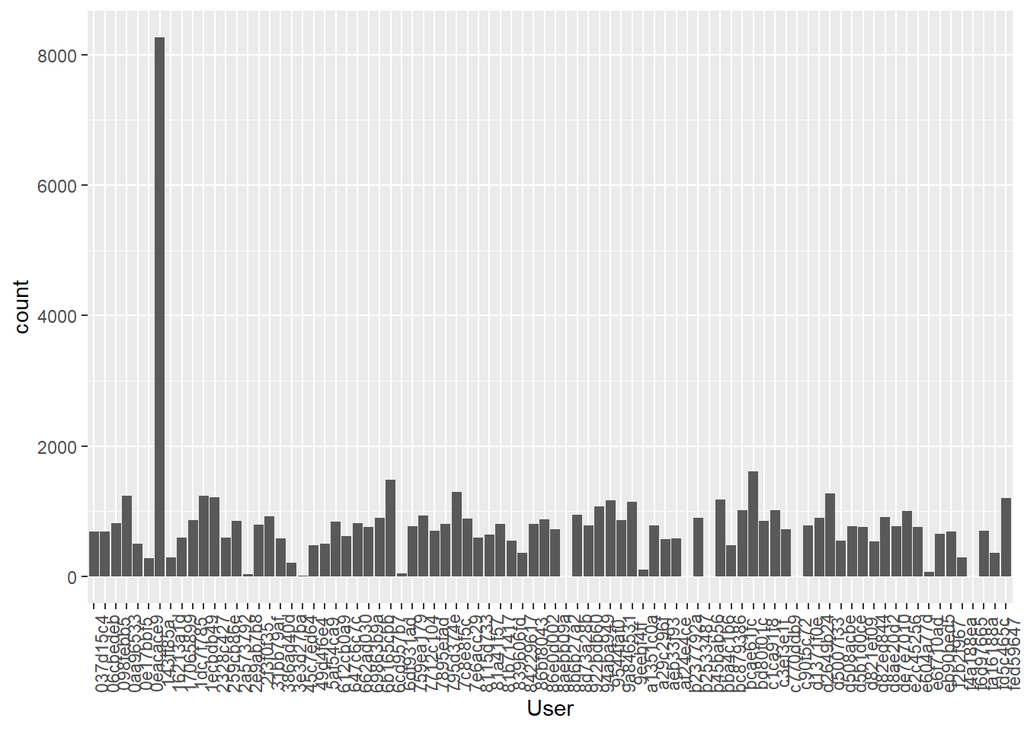

```r
# Cantidad de logs por usuario
df %>%
  ggplot(data = ., mapping = aes(x = User)) +
  geom_bar() +
  theme(axis.text.x = element_text(angle = 90))
```